# Exploratory Data Analysis

### 1. Problem Statement

In this python notebook, analysis of IPL matches from 2008 to 2018 is done using python packages like pandas, matplotlib and seaborn. This Exploratory Data Analysis will help us to find patterns in data, determining relationships in data. We will try to identify the team that has more chance to win the upcoming seasons by finding observations like success rate of each team, identify the team that has won maximum seasons, best defending and chasing team and analyse the toss decisions etc.

### 2. Data Loading and Description

• The dataset consists of the information about IPL matches held from 2008 to 2018.

### Importing the Packages and Dataset

```python
import numpy as np
import pandas as pd
import matplotlib.pyplot as plt
import seaborn as sns
%matplotlib inline

from subprocess import check_output

import warnings
warnings.filterwarnings('ignore')

ipl_match_data = pd.read_csv ('https://raw.githubusercontent.com/insaid2018/Term-1/master/Data/Projects/matches.csv' )
ipl_match_data.head(5)
```

|  | id | season | city | date | team1 | team2 | toss_winner | toss_decision | result | dl_applied | winner | win_by_runs | win_by_wickets | player_of_match | venue | umpire1 | umpire2 | umpire3 |
| --- | --- | --- | --- | --- | --- | --- | --- | --- | --- | --- | --- | --- | --- | --- | --- | --- | --- | --- |
| 0 | 1 | 2017 | Hyderabad | 2017-04-05 | Sunrisers Hyderabad | Royal Challengers Bangalore | Royal Challengers Bangalore | field | normal | 0 | Sunrisers Hyderabad | 35 | 0 | Yuvraj Singh | Rajiv Gandhi International Stadium, Uppal | AY Dandekar | NJ Llong | NaN |
| 1 | 2 | 2017 | Pune | 2017-04-06 | Mumbai Indians | Rising Pune Supergiant | Rising Pune Supergiant | field | normal | 0 | Rising Pune Supergiant | 0 | 7 | SPD Smith | Maharashtra Cricket Association Stadium | A Nand Kishore | S Ravi | NaN |
| 2 | 3 | 2017 | Rajkot | 2017-04-07 | Gujarat Lions | Kolkata Knight Riders | Kolkata Knight Riders | field | normal | 0 | Kolkata Knight Riders | 0 | 10 | CA Lynn | Saurashtra Cricket Association Stadium | Nitin Menon | CK Nandan | NaN |
| 3 | 4 | 2017 | Indore | 2017-04-08 | Rising Pune Supergiant | Kings XI Punjab | Kings XI Punjab | field | normal | 0 | Kings XI Punjab | 0 | 6 | GJ Maxwell | Holkar Cricket Stadium | AK Chaudhary | C Shamshuddin | NaN |
| 4 | 5 | 2017 | Bangalore | 2017-04-08 | Royal Challengers Bangalore | Delhi Daredevils | Royal Challengers Bangalore | bat | normal | 0 | Royal Challengers Bangalore | 15 | 0 | KM Jadhav | M Chinnaswamy Stadium | NaN | NaN | NaN |

### 3. Data Profiling

#### 3.1 Understanding the Dataset

Observing IPL match data rows and columns :

```python
ipl_match_data.shape
```

```
(696, 18)
```

```python
ipl_match_data.columns
```

```
Index(['id', 'season', 'city', 'date', 'team1', 'team2', 'toss_winner',
       'toss_decision', 'result', 'dl_applied', 'winner', 'win_by_runs',
       'win_by_wickets', 'player_of_match', 'venue', 'umpire1', 'umpire2',
       'umpire3'],
      dtype='object')
```

```python
ipl_match_data.info()
```

```
<class 'pandas.core.frame.DataFrame'>
RangeIndex: 696 entries, 0 to 695
Data columns (total 18 columns):
id                 696 non-null int64
season             696 non-null int64
city               689 non-null object
date               696 non-null object
team1              696 non-null object
team2              696 non-null object
toss_winner        696 non-null object
toss_decision      696 non-null object
result             696 non-null object
dl_applied         696 non-null int64
winner             693 non-null object
win_by_runs        696 non-null int64
win_by_wickets     696 non-null int64
player_of_match    693 non-null object
venue              696 non-null object
umpire1            695 non-null object
umpire2            695 non-null object
umpire3            60 non-null object
dtypes: int64(5), object(13)
memory usage: 98.0+ KB
```

```python
ipl_match_data.describe()
```

|  | id | season | dl_applied | win_by_runs | win_by_wickets |
| --- | --- | --- | --- | --- | --- |
| count | 696.000000 | 696.000000 | 696.000000 | 696.000000 | 696.000000 |
| mean | 974.103448 | 2012.965517 | 0.027299 | 13.472701 | 3.349138 |
| std | 2143.239623 | 3.069266 | 0.163070 | 23.607994 | 3.411398 |
| min | 1.000000 | 2008.000000 | 0.000000 | 0.000000 | 0.000000 |
| 25% | 174.750000 | 2010.000000 | 0.000000 | 0.000000 | 0.000000 |
| 50% | 348.500000 | 2013.000000 | 0.000000 | 0.000000 | 3.000000 |
| 75% | 522.250000 | 2016.000000 | 0.000000 | 19.000000 | 6.000000 |
| max | 7953.000000 | 2018.000000 | 1.000000 | 146.000000 | 10.000000 |

```python
ipl_match_data.isnull().sum()
```

```
id                   0
season               0
city                 7
date                 0
team1                0
team2                0
toss_winner          0
toss_decision        0
result               0
dl_applied           0
winner               3
win_by_runs          0
win_by_wickets       0
player_of_match      3
venue                0
umpire1              1
umpire2              1
umpire3            636
dtype: int64
```

From above output we can observe that **city** and **umpire3** are having maximum number of null values. We are going to deal with those null values in our next section.

### 3.3 Preprocessing

- **Dealing with missing values :**
  - Replacing missing entries of City from the Venue Column.
  - Replacing Rising Pune supergiant as Rising Pune supergiants.
  - Dropping the column 'Umpire3' as it has too many null values.
  - Replace city Bengaluru to Bangalore.
- Replacing missing entries of City from the Venue Column.

```python
ipl_match_data['city'].fillna( ipl_match_data['venue'].apply(lambda x: x[:5]),inplace = True)
ipl_match_data[ipl_match_data['city']== 'Dubai']
```

|  | id | season | city | date | team1 | team2 | toss_winner | toss_decision | result | dl_applied | winner | win_by_runs | win_by_wickets | player_of_match | venue | umpire1 | umpire2 | umpire3 |
| --- | --- | --- | --- | --- | --- | --- | --- | --- | --- | --- | --- | --- | --- | --- | --- | --- | --- | --- |
| 461 | 462 | 2014 | Dubai | 2014-04-19 | Mumbai Indians | Royal Challengers Bangalore | Royal Challengers Bangalore | field | normal | 0 | Royal Challengers Bangalore | 0 | 7 | PA Patel | Dubai International Cricket Stadium | Aleem Dar | AK Chaudhary | NaN |
| 462 | 463 | 2014 | Dubai | 2014-04-19 | Kolkata Knight Riders | Delhi Daredevils | Kolkata Knight Riders | bat | normal | 0 | Delhi Daredevils | 0 | 4 | JP Duminy | Dubai International Cricket Stadium | Aleem Dar | VA Kulkarni | NaN |
| 466 | 467 | 2014 | Dubai | 2014-04-23 | Chennai Super Kings | Rajasthan Royals | Rajasthan Royals | field | normal | 0 | Chennai Super Kings | 7 | 0 | RA Jadeja | Dubai International Cricket Stadium | HDPK Dharmasena | RK Illingworth | NaN |
| 468 | 469 | 2014 | Dubai | 2014-04-25 | Sunrisers Hyderabad | Delhi Daredevils | Sunrisers Hyderabad | bat | normal | 0 | Sunrisers Hyderabad | 4 | 0 | AJ Finch | Dubai International Cricket Stadium | M Erasmus | S Ravi | NaN |
| 469 | 470 | 2014 | Dubai | 2014-04-25 | Mumbai Indians | Chennai Super Kings | Mumbai Indians | bat | normal | 0 | Chennai Super Kings | 0 | 7 | MM Sharma | Dubai International Cricket Stadium | BF Bowden | M Erasmus | NaN |
| 474 | 475 | 2014 | Dubai | 2014-04-28 | Royal Challengers Bangalore | Kings XI Punjab | Kings XI Punjab | field | normal | 0 | Kings XI Punjab | 0 | 5 | Sandeep Sharma | Dubai International Cricket Stadium | BF Bowden | S Ravi | NaN |
| 476 | 477 | 2014 | Dubai | 2014-04-30 | Sunrisers Hyderabad | Mumbai Indians | Mumbai Indians | field | normal | 0 | Sunrisers Hyderabad | 15 | 0 | B Kumar | Dubai International Cricket Stadium | HDPK Dharmasena | M Erasmus | NaN |

- Replacing Rising Pune supergiant as Rising Pune supergiants.

```python
ipl_match_data.replace( 'Rising Pune Supergiant', 'Rising Pune Supergiants',inplace = True)
ipl_match_data.head(2)
```

|  | id | season | city | date | team1 | team2 | toss_winner | toss_decision | result | dl_applied | winner | win_by_runs | win_by_wickets | player_of_match | venue | umpire1 | umpire2 | umpire3 |
| --- | --- | --- | --- | --- | --- | --- | --- | --- | --- | --- | --- | --- | --- | --- | --- | --- | --- | --- |
| 0 | 1 | 2017 | Hyderabad | 2017-04-05 | Sunrisers Hyderabad | Royal Challengers Bangalore | Royal Challengers Bangalore | field | normal | 0 | Sunrisers Hyderabad | 35 | 0 | Yuvraj Singh | Rajiv Gandhi International Stadium, Uppal | AY Dandekar | NJ Llong | NaN |
| 1 | 2 | 2017 | Pune | 2017-04-06 | Mumbai Indians | Rising Pune Supergiants | Rising Pune Supergiants | field | normal | 0 | Rising Pune Supergiants | 0 | 7 | SPD Smith | Maharashtra Cricket Association Stadium | A Nand Kishore | S Ravi | NaN |

- Dropping the column 'Umpire3' as it has too many null values.

```python
ipl_match_data.drop('umpire3', axis=1, inplace=True)
ipl_match_data.columns.unique()
```

```
Index(['id', 'season', 'city', 'date', 'team1', 'team2', 'toss_winner',
       'toss_decision', 'result', 'dl_applied', 'winner', 'win_by_runs',
       'win_by_wickets', 'player_of_match', 'venue', 'umpire1', 'umpire2'],
      dtype='object')
```

- Replace city Bengaluru to Bangalore.

```python
ipl_match_data.replace( 'Bengaluru', 'Bangalore',inplace = True)
ipl_match_data['city'].unique()
```

```
array(['Hyderabad', 'Pune', 'Rajkot', 'Indore', 'Bangalore', 'Mumbai',
       'Kolkata', 'Delhi', 'Chandigarh', 'Kanpur', 'Jaipur', 'Chennai',
       'Cape Town', 'Port Elizabeth', 'Durban', 'Centurion',
       'East London', 'Johannesburg', 'Kimberley', 'Bloemfontein',
       'Ahmedabad', 'Cuttack', 'Nagpur', 'Dharamsala', 'Kochi',
       'Visakhapatnam', 'Raipur', 'Ranchi', 'Abu Dhabi', 'Sharjah',
       'Dubai', 'Mohali'], dtype=object)
```

```python
ipl_match_data.columns
```

```
Index(['id', 'season', 'city', 'date', 'team1', 'team2', 'toss_winner',
       'toss_decision', 'result', 'dl_applied', 'winner', 'win_by_runs',
       'win_by_wickets', 'player_of_match', 'venue', 'umpire1', 'umpire2'],
      dtype='object')
```

```python
ipl_match_data['season'].unique()
```

```
array([2017, 2008, 2009, 2010, 2011, 2012, 2013, 2014, 2015, 2016, 2018],
      dtype=int64)
```

```python
ipl_match_data['team1'].unique()
```

```
array(['Sunrisers Hyderabad', 'Mumbai Indians', 'Gujarat Lions',
       'Rising Pune Supergiants', 'Royal Challengers Bangalore',
       'Kolkata Knight Riders', 'Delhi Daredevils', 'Kings XI Punjab',
       'Chennai Super Kings', 'Rajasthan Royals', 'Deccan Chargers',
       'Kochi Tuskers Kerala', 'Pune Warriors'], dtype=object)
```

### 4. Questions

4.1 Number of matches held season wise

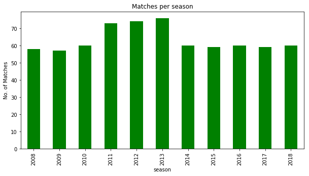

```python
ipl_match_data.groupby("season")["id"].count().plot(kind="bar",title="Matches per season", color=['green'],figsize=(10,5))
plt.ylabel("No. of Matches")
```

**Observation**: Most number of matches has played in season 2013 - 76 matches

4.2 Number of matches won by each team at each season

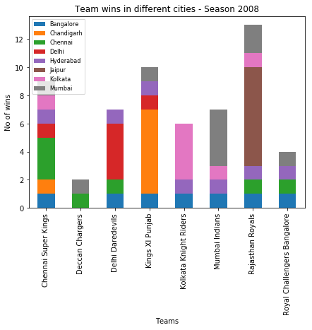

```python
    stack_plot = ipl_match_data[ipl_match_data['season'] == 2008].groupby(['winner', 'city'])['id'].count().unstack()
    final_plot = stack_plot.plot(kind='bar',stacked=True, title = 'Team wins in different cities - Season 2008', figsize = (7,5))
    final_plot.set_xlabel("Teams")
    final_plot.set_ylabel("No of wins")
    final_plot.legend(loc='best', prop={'size':8})
```

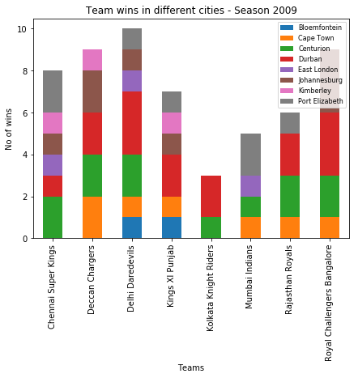

```python
    stack_plot = ipl_match_data[ipl_match_data['season'] == 2009].groupby(['winner', 'city'])['id'].count().unstack()
    final_plot = stack_plot.plot(kind='bar',stacked=True, title = 'Team wins in different cities - Season 2009', figsize = (7,5))
    final_plot.set_xlabel("Teams")
    final_plot.set_ylabel("No of wins")
    final_plot.legend(loc='best', prop={'size':8})
```

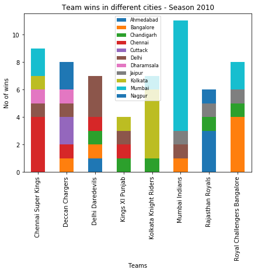

```python
    stack_plot = ipl_match_data[ipl_match_data['season'] == 2010].groupby(['winner', 'city'])['id'].count().unstack()
    final_plot = stack_plot.plot(kind='bar',stacked=True, title = 'Team wins in different cities - Season 2010', figsize = (7,5))
    final_plot.set_xlabel("Teams")
    final_plot.set_ylabel("No of wins")
    final_plot.legend(loc='best', prop={'size':8})
```

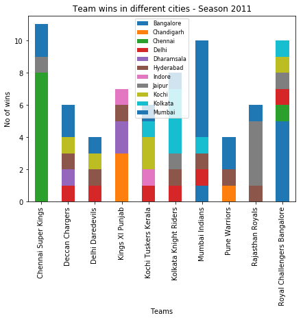

```python
    stack_plot = ipl_match_data[ipl_match_data['season'] == 2011].groupby(['winner', 'city'])['id'].count().unstack()
    final_plot = stack_plot.plot(kind='bar',stacked=True, title = 'Team wins in different cities - Season 2011', figsize = (7,5))
    final_plot.set_xlabel("Teams")
    final_plot.set_ylabel("No of wins")
    final_plot.legend(loc='best', prop={'size':8})
```

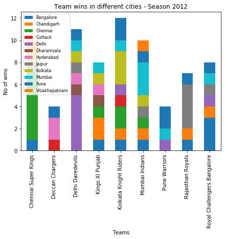

```python
    stack_plot = ipl_match_data[ipl_match_data['season'] == 2012].groupby(['winner', 'city'])['id'].count().unstack()
    final_plot = stack_plot.plot(kind='bar',stacked=True, title = 'Team wins in different cities - Season 2012', figsize = (7,5))
    final_plot.set_xlabel("Teams")
    final_plot.set_ylabel("No of wins")
    final_plot.legend(loc='best', prop={'size':8})
```

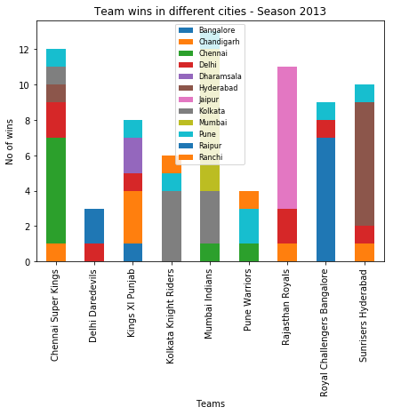

```python
    stack_plot = ipl_match_data[ipl_match_data['season'] == 2013].groupby(['winner', 'city'])['id'].count().unstack()
    final_plot = stack_plot.plot(kind='bar',stacked=True, title = 'Team wins in different cities - Season 2013', figsize = (7,5))
    final_plot.set_xlabel("Teams")
    final_plot.set_ylabel("No of wins")
    final_plot.legend(loc='best', prop={'size':8})
```

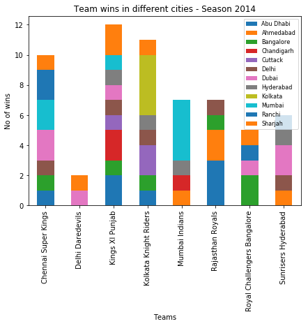

```python
    stack_plot = ipl_match_data[ipl_match_data['season'] == 2014].groupby(['winner', 'city'])['id'].count().unstack()
    final_plot = stack_plot.plot(kind='bar',stacked=True, title = 'Team wins in different cities - Season 2014', figsize = (7,5))
    final_plot.set_xlabel("Teams")
    final_plot.set_ylabel("No of wins")
    final_plot.legend(loc='best', prop={'size':8})
```

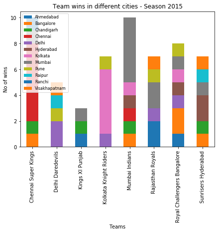

```python
    stack_plot = ipl_match_data[ipl_match_data['season'] == 2015].groupby(['winner', 'city'])['id'].count().unstack()
    final_plot = stack_plot.plot(kind='bar',stacked=True, title = 'Team wins in different cities - Season 2015', figsize = (7,5))
    final_plot.set_xlabel("Teams")
    final_plot.set_ylabel("No of wins")
    final_plot.legend(loc='best', prop={'size':8})
```

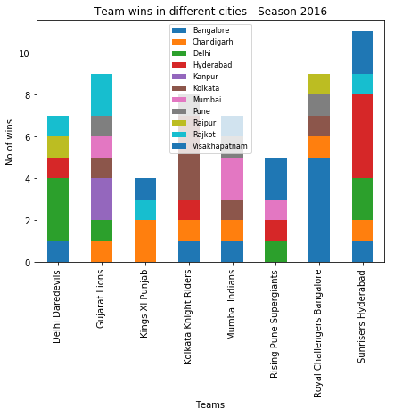

```python
    stack_plot = ipl_match_data[ipl_match_data['season'] == 2016].groupby(['winner', 'city'])['id'].count().unstack()
    final_plot = stack_plot.plot(kind='bar',stacked=True, title = 'Team wins in different cities - Season 2016', figsize = (7,5))
    final_plot.set_xlabel("Teams")
    final_plot.set_ylabel("No of wins")
    final_plot.legend(loc='best', prop={'size':8})
```

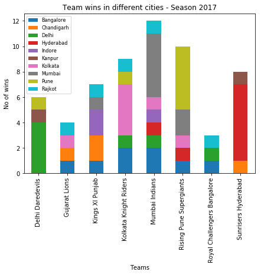

```python
    stack_plot = ipl_match_data[ipl_match_data['season'] == 2017].groupby(['winner', 'city'])['id'].count().unstack()
    final_plot = stack_plot.plot(kind='bar',stacked=True, title = 'Team wins in different cities - Season 2017', figsize = (7,5))
    final_plot.set_xlabel("Teams")
    final_plot.set_ylabel("No of wins")
    final_plot.legend(loc='best', prop={'size':8})
```

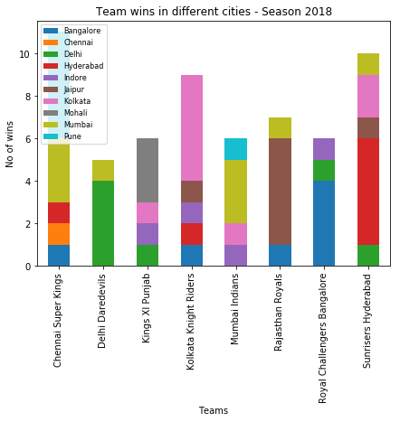

```python
    stack_plot = ipl_match_data[ipl_match_data['season'] == 2018].groupby(['winner', 'city'])['id'].count().unstack()
    final_plot = stack_plot.plot(kind='bar',stacked=True, title = 'Team wins in different cities - Season 2018', figsize = (7,5))
    final_plot.set_xlabel("Teams")
    final_plot.set_ylabel("No of wins")
    final_plot.legend(loc='best', prop={'size':8})
```

4.3 Total matches played by each team

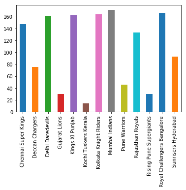

```python
total_matches_played = ipl_match_data['team1'].value_counts()+ ipl_match_data['team2'].value_counts()
total_matches_played.plot.bar()
```

```python
total_matches_played = ipl_match_data['team1'].value_counts()+ ipl_match_data['team2'].value_counts()
total_matches_played
```

```
Chennai Super Kings            147
Deccan Chargers                 75
Delhi Daredevils               161
Gujarat Lions                   30
Kings XI Punjab                162
Kochi Tuskers Kerala            14
Kolkata Knight Riders          164
Mumbai Indians                 171
Pune Warriors                   46
Rajasthan Royals               133
Rising Pune Supergiants         30
Royal Challengers Bangalore    166
Sunrisers Hyderabad             93
dtype: int64
```

**Observation** : Mumbai Indians is the team played most number of matches - 171 and Kochi Tuskers Kerala is the team played least number of matches - 14.

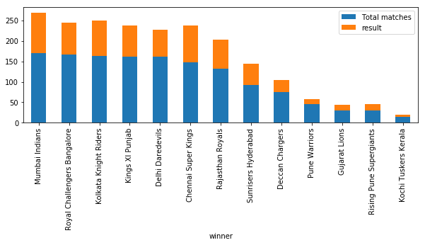

```python
matches_won = ipl_match_data.groupby('winner').count()
matches_won

total_matches = ipl_match_data['team1'].value_counts()+ ipl_match_data['team2'].value_counts()
total_matches

matches_won['Total matches']=total_matches
matches_won[["Total matches","result"]].sort_values(by=["Total matches"],ascending=False).plot.bar(stacked=True,figsize=(10,3))
```

**Observation**: Mumbai Indians, Chennai Super Kings has more wins against total number of matches played by each team and Pune Warriors has least wins against total matches played by them.

4.4 How many matches won by each team ?

```python
matches_won = ipl_match_data.groupby('winner').count()
matches_won["id"]
```

```
winner
Chennai Super Kings            90
Deccan Chargers                29
Delhi Daredevils               67
Gujarat Lions                  13
Kings XI Punjab                76
Kochi Tuskers Kerala            6
Kolkata Knight Riders          86
Mumbai Indians                 98
Pune Warriors                  12
Rajasthan Royals               70
Rising Pune Supergiants        15
Royal Challengers Bangalore    79
Sunrisers Hyderabad            52
Name: id, dtype: int64
```

**Observations** : Again Mumbai Indians is leading the table and won 98 matches in all IPL seasons (2008-2018)

4.5 Team had won by maximum runs?

```python
max_runs = ipl_match_data.sort_values('win_by_runs', ascending = False).head(10) #top 10
max_runs[['season','winner','win_by_runs']]
```

|  | season | winner | win_by_runs |
| --- | --- | --- | --- |
| 43 | 2017 | Mumbai Indians | 146 |
| 619 | 2016 | Royal Challengers Bangalore | 144 |
| 59 | 2008 | Kolkata Knight Riders | 140 |
| 556 | 2015 | Royal Challengers Bangalore | 138 |
| 410 | 2013 | Royal Challengers Bangalore | 130 |
| 295 | 2011 | Kings XI Punjab | 111 |
| 114 | 2008 | Rajasthan Royals | 105 |
| 676 | 2018 | Mumbai Indians | 102 |
| 182 | 2010 | Mumbai Indians | 98 |
| 541 | 2015 | Chennai Super Kings | 97 |

Mumbai Indians won the match by most runs i.e. 146 in season 2017. Mumbai Indians and Royal challengers Bangalore are the team who won the matches by most number of runs 3 times in all seasons.

4.6 Team had won by maximum wickets?

```python
max_wickets =ipl_match_data[ipl_match_data['win_by_wickets'] == 10]
max_wickets['winner'].value_counts()
```

```
Royal Challengers Bangalore    3
Sunrisers Hyderabad            1
Deccan Chargers                1
Kings XI Punjab                1
Chennai Super Kings            1
Delhi Daredevils               1
Rajasthan Royals               1
Mumbai Indians                 1
Kolkata Knight Riders          1
Name: winner, dtype: int64
```

**Observation** : Royal Challengers Bangalore is a best chasing team, had won the match many times with maximum wickets.

4.7 Comparison between Number of matches won by each team and total matches played

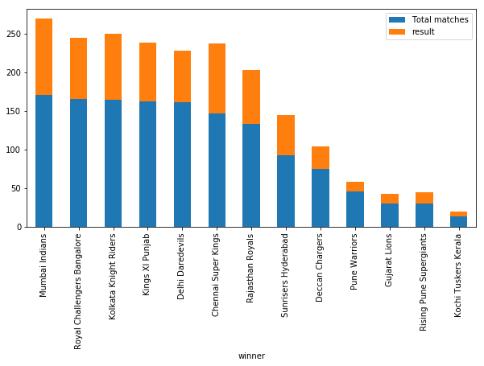

```python
matches_won = ipl_match_data.groupby('winner').count()
matches_won

total_matches = ipl_match_data['team1'].value_counts()+ ipl_match_data['team2'].value_counts()
total_matches

matches_won['Total matches']=total_matches
matches_won[["Total matches","result"]].sort_values(by=["Total matches"],ascending=False).plot.bar(stacked=True,figsize=(10,5))
```

4.8 Success Rate of each team?

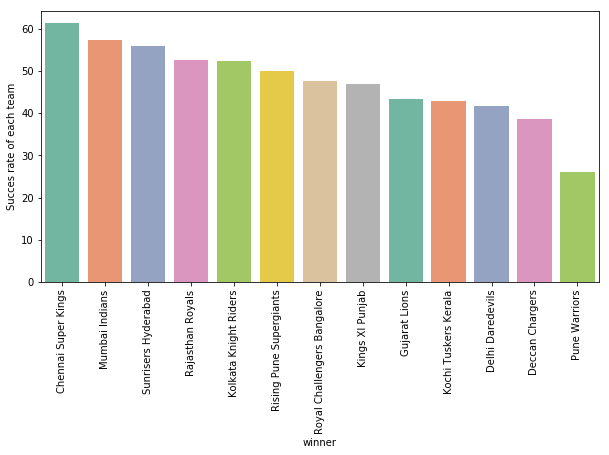

```python
match_succes_rate = (matches_won["id"]/total_matches)*100
data = match_succes_rate.sort_values(ascending = False)
plt.figure(figsize=(10,5))
sns.barplot(x = data.index, y = data, palette="Set2");
plt.ylabel('Succes rate of each team')
plt.xticks(rotation=90)
```

**Observation** :Chennai Super Kings have highest winning success rate (61.2%) , followed by Mumbai Indians (57.3%).

4.9 Which team won maximum seasons ?

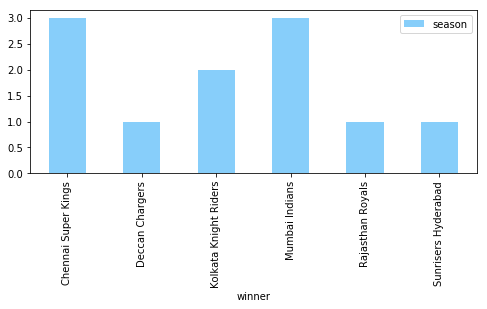

```python
season_winner = ipl_match_data.groupby('season')['season','winner'].tail(1)
season_winner.sort_values(by="season",ascending=True)
season_winner.groupby('winner').count().plot.bar(color = 'lightskyblue' , figsize=(8,3))
```

**Observation**: Chennai Super Kings and Mumbai Indians won 3 seasons each

[figure not shown]

```python
plt.figure(figsize=(7,3))
ipl_match_data['player_of_match'].value_counts()[:10].plot.bar()
plt.title('Top 10 high performing Players')
```

**Observations** : Chris Gayle is leading the chart with most valuable player of all the season, followed by ABD and Rohit Sharma.

4.11 Best Defending Teams

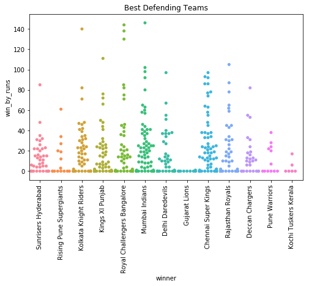

```python
plt.figure(figsize=(8,5))
sns.swarmplot(y='win_by_runs',x='winner',data=ipl_match_data)
plt.xticks(rotation=90)
plt.title('Best Defending Teams')
plt.show()
```

Mumbai Indians, Royal Challangers Bangalore, Chennai Super kings and Sunrisers Hyderabad are best Defending teams.

4.12 Best Chasing Teams

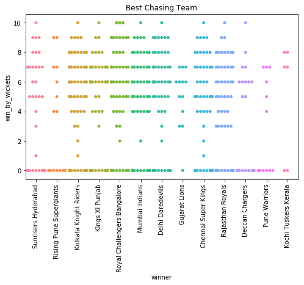

```python
plt.figure(figsize=(8,5))
sns.swarmplot(y='win_by_wickets',x='winner',data=ipl_match_data)
plt.xticks(rotation=90)
plt.title('Best Chasing Team')
plt.show()
```

Royal Challangers Bangalore, Mumbai Indians and Kolkata Knight Ridersare the best Chasing teams.

4.13 Top 10 high performing Players

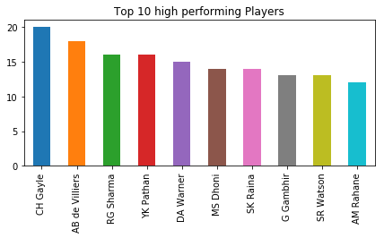

```python
plt.figure(figsize=(7,3))
ipl_match_data['player_of_match'].value_counts()[:10].plot.bar()
plt.title('Top 10 high performing Players')
```

4.14 Toss Decision across matches

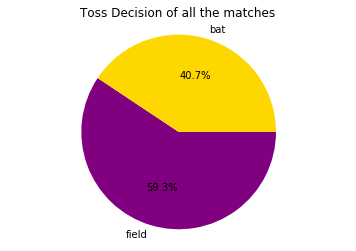

```python
toss=ipl_match_data['toss_decision'].value_counts()
labels=np.array(toss.index)
sizes = toss.values
colors = ['purple', 'gold']
# Plot
plt.pie(sizes, labels=labels, colors=colors, autopct='%1.1f%%', counterclock=False)
plt.title('Toss Decision of all the matches')
plt.axis('equal')
plt.show()
```

Observations : 59.3% of the toss winning teams have opted for Feilding while 40.7% have opted for Batting.

4.15 Toss Decision across seasons

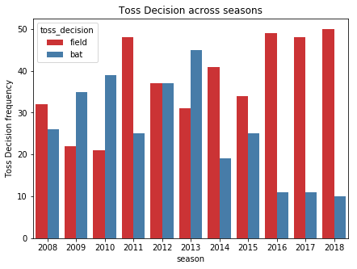

```python
plt.figure(figsize=(7,5))
sns.countplot(x = 'season' , hue='toss_decision',data=ipl_match_data,palette="Set1")
plt.ylabel('Toss Decision frequency')
plt.title('Toss Decision across seasons')
```

In season 2008,2011 and, from 2014 to 2018 teams were more interested in chasing the target, while in remaining seasons teams were preferred to set a traget for opponent and they have chosen to bat first.

4.16 How does Toss decision varied Season wise by each team ?

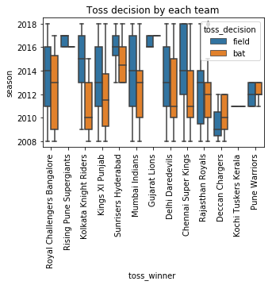

```python
plt.figure(figsize=(5,3))
sns.boxplot(x="toss_winner", y="season", hue = 'toss_decision', data=ipl_match_data)
plt.xlabel('toss_winner ')
plt.xticks(rotation=90)
plt.title('Toss decision by each team')
```

4.17 Toss winning : Does it really affects on the match results?

```python
tosswin_win = ipl_match_data['id'][ipl_match_data['toss_winner'] == ipl_match_data['winner']].count()
total_matches=ipl_match_data['id'].count()
Success_rate = ((ipl_match_data[ipl_match_data['toss_winner'] == ipl_match_data['winner']].count())/(total_matches))*100

print("Number of matches in which Toss winner is the game winner is :",tosswin_win, "out of",total_matches," ie.,", Success_rate["id"],"%" )
```

```
Number of matches in which Toss winner is the game winner is : 357 out of 696  ie., 51.293103448275865 %
```

4.18 Toss Decision in which Toss winner is the game winner

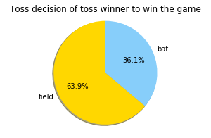

```python
tosswin_winner = ipl_match_data['toss_decision'][ipl_match_data['toss_winner'] == ipl_match_data['winner']].value_counts()
labels=np.array(tosswin_winner.index)
sizes = tosswin_winner.values
colors = ['gold', 'lightskyblue']

plt.figure(figsize=(5,3))
plt.pie(sizes, labels=labels, colors=colors,
        autopct='%1.1f%%', shadow=True,startangle=90)

plt.title('Toss decision of toss winner to win the game')
plt.axis('equal')
plt.show()
```

63.9% of the toss winning teams had decided to field first while 36.1% had decided to Bat first and won the matches.

4.19 Top 10 Cities to hold match

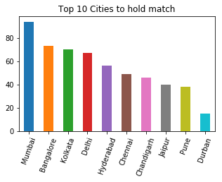

```python
plt.figure(figsize=(5,3))
ax=ipl_match_data['city'].value_counts()[:10].plot.bar()
plt.title('Top 10 Cities to hold match')
plt.xticks(rotation=70)
```

4.20 In which city does each team has won more matches ?

```python
a=ipl_match_data.groupby(['winner','city']).size().reset_index(name='win_counts')
a=a.sort_values("win_counts",ascending=False)
a.groupby("winner").head(1)
```

|  | winner | city | win_counts |
| --- | --- | --- | --- |
| 127 | Mumbai Indians | Mumbai | 48 |
| 109 | Kolkata Knight Riders | Kolkata | 42 |
| 4 | Chennai Super Kings | Chennai | 34 |
| 164 | Royal Challengers Bangalore | Bangalore | 34 |
| 149 | Rajasthan Royals | Jaipur | 29 |
| 43 | Delhi Daredevils | Delhi | 27 |
| 189 | Sunrisers Hyderabad | Hyderabad | 25 |
| 74 | Kings XI Punjab | Chandigarh | 22 |
| 161 | Rising Pune Supergiants | Pune | 5 |
| 137 | Pune Warriors | Pune | 4 |
| 68 | Gujarat Lions | Rajkot | 3 |
| 33 | Deccan Chargers | Mumbai | 3 |
| 95 | Kochi Tuskers Kerala | Kochi | 2 |

Teams had won more matches in their home grounds.

4.21 Top 10 venue to hold matches

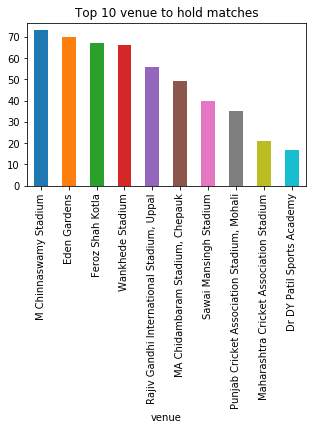

```python
#top 10 venue to hold max number of matches
plt.figure(figsize=(5,3))
venue=ipl_match_data.groupby('venue')["id"].count()
ax =venue.sort_values(ascending=False).head(10).plot.bar(figsize=(5,3))
plt.title('Top 10 venue to hold matches')
plt.xticks(rotation=90)
```

M Chinnaswamy Stadium had hold highest number of matches (73) followed by Eden Gardens (70).

4.22 Identify if each Venue is Best Suited to opt for batting or fielding based on previous matches won on that venue

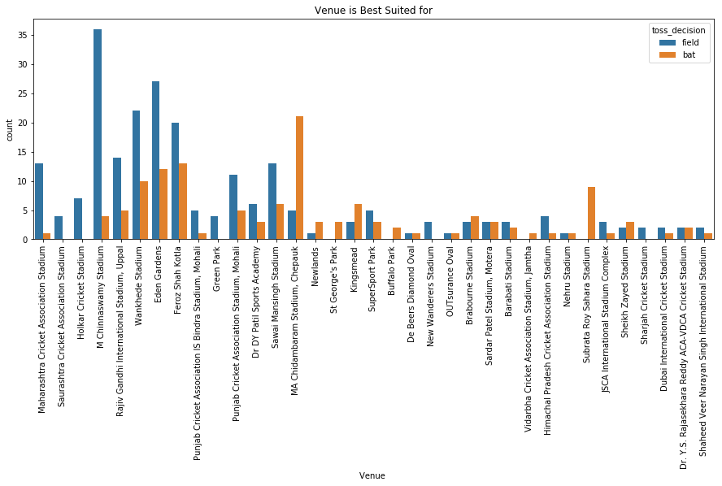

```python
plt.figure(figsize=(15,5))
venue_suit_for =ipl_match_data[ipl_match_data['toss_winner'] == ipl_match_data['winner']]
sns.countplot(x='venue',hue='toss_decision',data=venue_suit_for)
plt.xlabel('Venue ')
plt.title('Venue is Best Suited for')
plt.xticks(rotation=90)
```

M Chinnaswamy stadium and Eden Gardens is best Suited for Feilding and MA Chidambaram Stadium ,Chepauk is best suited for Batting.

4.23 Hypothesis:

Mumbai Indians and Chennai Super Kings likely to win more matches

### 5. Conclusion

[output not shown]